# Analiza rynku nieruchomości w 2018 roku

Kornelia Ćwik, Adam Rubczyński

11 05 2020

## Wstęp

Analiza rynku nieruchomości została przygotowana w oparciu o dane z Banku Danych Lokalnych GUSu. Wykorzystane zostały dane z 2018 roku na temat rynkowej sprzedaży lokali mieszkalnych, stopy bezrobocia rejestrowanego oraz dochodów powiatów w przeliczeniu na 1 mieszkańca.  
W raporcie nie posługiwaliśmy się wartością bezwzględną sprzedanych mieszkań, ale wartością przeliczoną na 1000 mieszkańców. W celu jej obliczenia wykorzystaliśmy dane o ludności z Narodowego Spisu Powszechnego z 2011 roku. Dane GUSu o dochodach w przeliczeniu na 1 mieszkańca również zostały stworzone w oparciu o ten spis.

## Przygotowanie danych

```r
powiaty <- st_read(dsn = 'dane/jednostki_administracyjne/Powiaty.shp')
nieruchomosci <- readxl::read_xlsx('dane/rynek_nieruchomosci.xlsx', sheet = 2)
bezrobocie <- readxl::read_xlsx('dane/bezrobocie_rejestrowane.xlsx', sheet = 2)
dochody <- readxl::read_xlsx('dane/dochody_na_mieszkanca.xlsx', sheet = 2)
spis <- readxl::read_xlsx('dane/spis_powszechny_2011.xlsx', sheet = 2)

colnames(bezrobocie)[1] <- 'JPT_KOD_JE'
colnames(nieruchomosci)[1] <- 'JPT_KOD_JE'
colnames(dochody)[1] <- 'JPT_KOD_JE'
colnames(spis)[1] <- 'JPT_KOD_JE'


powiaty$JPT_KOD_JE <- paste0(powiaty$JPT_KOD_JE, '000')

df <- powiaty %>%
  left_join(bezrobocie, by = c(('JPT_KOD_JE')))

df <- df %>%
  left_join(dochody, by = c(('JPT_KOD_JE')))

df <- df %>%
  left_join(nieruchomosci, by = c(('JPT_KOD_JE')))

df <- df %>%
  left_join(spis, by = c(('JPT_KOD_JE')))

df %>%
  mutate(Lokale_na_1000_mieszk = (Lokale/Ludność)*1000) -> df

df %>%
  mutate(Lokale_pierwotny_procent = Lokale_pierwotny/Lokale*100) -> df
```

## Podział na rynek pierwotny i wtórny

Na poniższym wykresie przedstawiono udział mieszkań z rynku pierwotnego we wszystkich transkacjach sprzedaży.

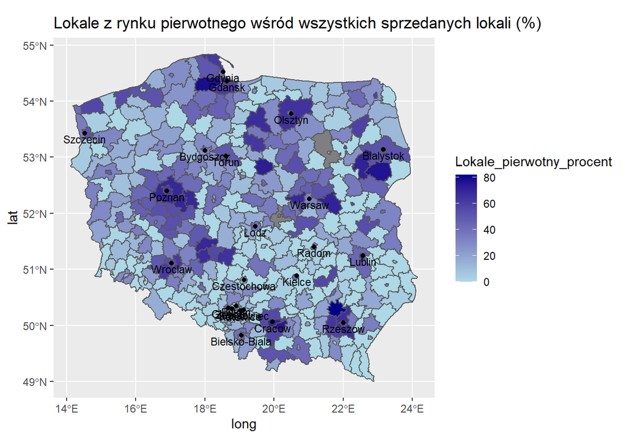

```r
lnd_point = st_point(c(16.56, 52.24))           #poznań
lnd_geom = st_sfc(lnd_point, crs = 4326)
#,

ggplot(data = df) +
  geom_sf(data = df, aes(fill = Lokale_pierwotny_procent)) +
  geom_point(data = world.cities[world.cities$country.etc == 'Poland' & world.cities$pop >= 150000,],
             aes(x=long, y=lat)) +
  geom_text(data = world.cities[world.cities$country.etc == 'Poland' & world.cities$pop >= 150000,],
             aes(x=long, y=lat, label = name),size = 3, nudge_y = -0.1) +
  labs(title = 'Lokale z rynku pierwotnego wśród wszystkich sprzedanych lokali (%)') +
  scale_fill_gradient2(mid = 'lightblue', high = 'darkblue')
```

Widać, że duży odsetek mieszkań z rynku pierwotnego występuje w powiatach sąsiadujących z największymi polskimi miastami, między innymi Warszawą, Poznaniem czy Krakowem.

Powiaty, w których mieszkania z rynku pierwotnego stanowią największą część sprzedanych mieszkań:

```r
df %>%
  st_set_geometry(NULL) %>%
  arrange(by = desc(Lokale_pierwotny_procent)) %>%
  top_n(10) %>%
  select(JPT_NAZWA_, Lokale_pierwotny_procent, Lokale_pierwotny)
```

```
##                 JPT_NAZWA_ Lokale_pierwotny_procent Lokale_pierwotny
## 1      powiat kolbuszowski                 82.25806               51
## 2          powiat kartuski                 78.61635              500
## 3           powiat bielski                 76.66667               46
## 4          powiat wielicki                 75.13612              414
## 5         powiat sierpecki                 73.03922              149
## 6  powiat wysokomazowiecki                 71.42857               50
## 7            powiat miński                 71.19497              566
## 8           powiat średzki                 70.32641              237
## 9            powiat Kraków                 70.17695             8130
## 10       powiat wrzesiński                 69.51220              456
```

## Kartogramy

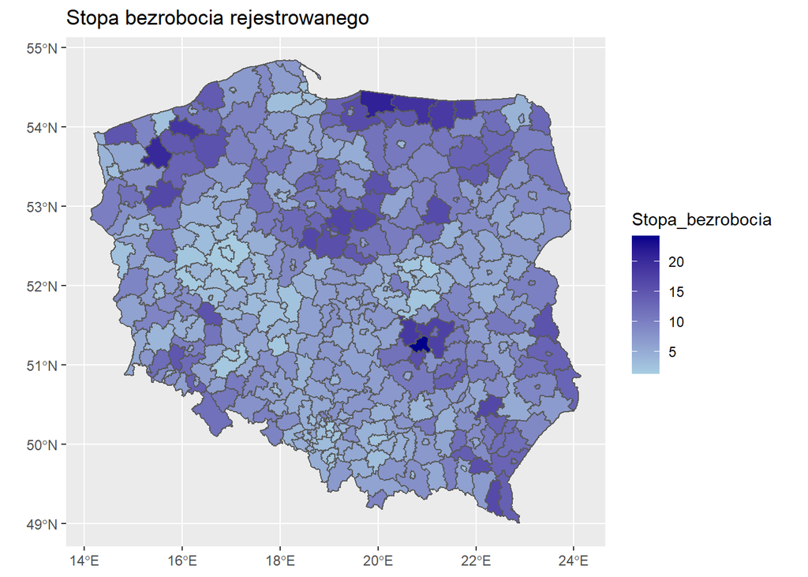

```r
ggplot(data = df, aes(fill = Stopa_bezrobocia)) +
  geom_sf() +
  labs(title = 'Stopa bezrobocia rejestrowanego') +
  scale_fill_gradient2(mid = 'lightblue', high = 'darkblue')
```

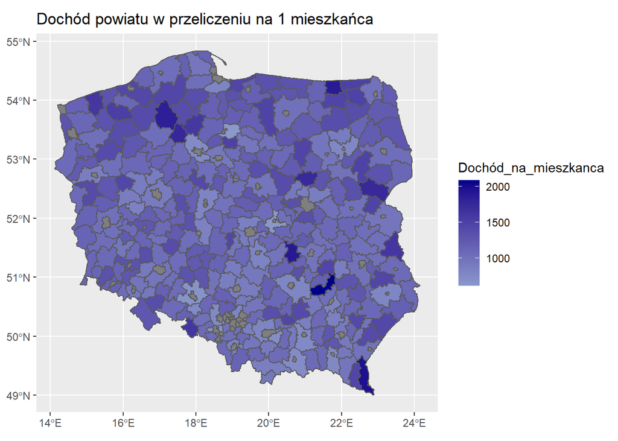

```r
ggplot(data = df, aes(fill = Dochód_na_mieszkanca)) +
  geom_sf() +
  labs(title = 'Dochód powiatu w przeliczeniu na 1 mieszkańca') +
  scale_fill_gradient2(mid = 'lightblue', high = 'darkblue')
```

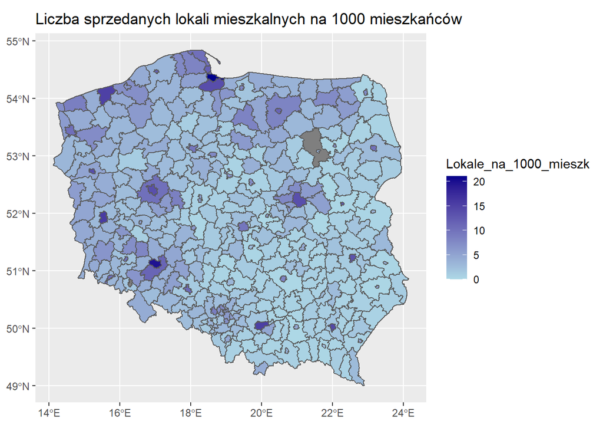

```r
ggplot(data = df, aes(fill = Lokale_na_1000_mieszk)) +
  geom_sf() +
  labs(title = 'Liczba sprzedanych lokali mieszkalnych na 1000 mieszkańców') +
  scale_fill_gradient2(mid = 'lightblue', high = 'darkblue')
```

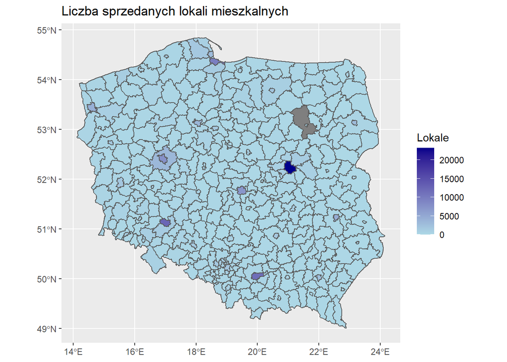

```r
ggplot(data = df, aes(fill = Lokale)) +
  geom_sf() +
  labs(title = 'Liczba sprzedanych lokali mieszkalnych') +
  scale_fill_gradient2(mid = 'lightblue', high = 'darkblue')
```

## Sprzedaż lokali mieszkalnych a liczba ludności

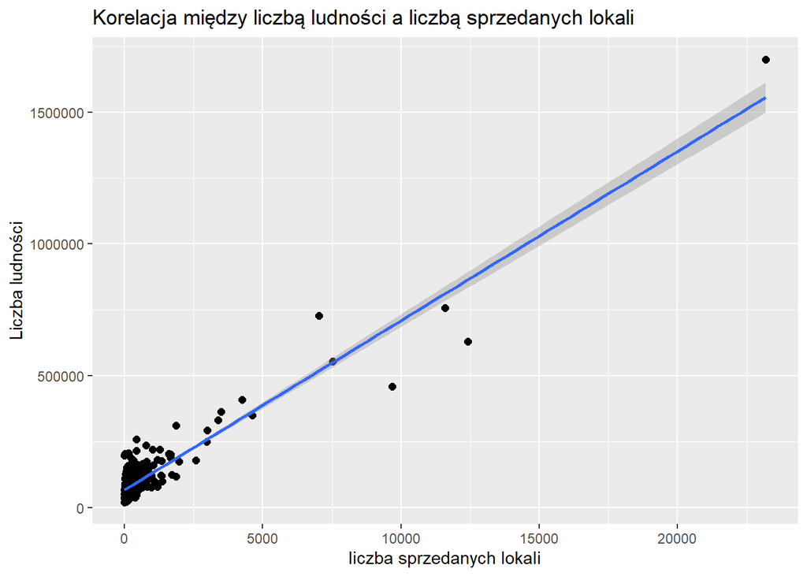

```r
ggplot(df,aes(x = Lokale, y= Ludność)) +
  geom_point(size = 2) + geom_smooth(method = lm) +
labs(title = "Korelacja między liczbą ludności a liczbą sprzedanych lokali", x= "liczba sprzedanych lokali", y = "Liczba ludności")
```

```r
cor.test(df$Lokale, df$Ludność)
```

```
##
##  Pearson's product-moment correlation
##
## data:  df$Lokale and df$Ludność
## t = 50.14, df = 376, p-value < 2.2e-16
## alternative hypothesis: true correlation is not equal to 0
## 95 percent confidence interval:
##  0.9181975 0.9446781
## sample estimates:
##       cor
## 0.9326834
```

W celu zbadania korelacji pomiędzy liczbą lokali sprzedanych, a liczbą ludności danego powiatu posłużylismy się wskaźnikiem korelacji Pearsona oraz wykresem. Jak widzimy wartość współczynnika wynosi 0,93, co oznacza bardzo silną korelacji. Jest to wartość zbliżona do 1, która oznacza całkowitą zależność. Wartość p-value jest zdecydowanie mniejsza od 0.05 więc wynik jest istotny i możemy odrzucić hipotezę zerową mówiącą o tym, że korelacja między tymi dwoma zmiennymi jest równa 0.

```r
df%>%as.data.frame%>%top_n(1,Ludność)%>%select(JPT_NAZWA_,Ludność,Lokale)
```

```
##        JPT_NAZWA_ Ludność Lokale
## 1 powiat Warszawa 1700612  23192
```

Widzimy, że powiatem ze zdecydowanie największą ilością mieszkańców oraz sprzedanych lokali jest powiat miasta Warszawa.

## Sprzedaż lokali mieszkalnych a dochody powiatu

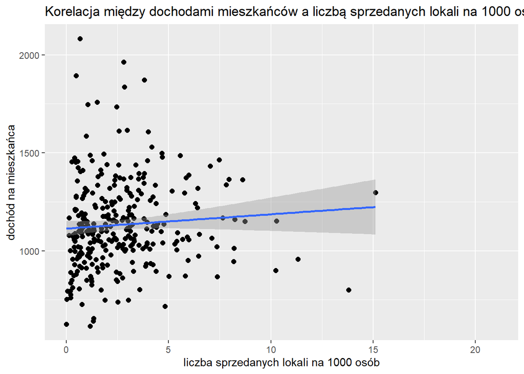

```r
ggplot(df,aes(x = Lokale_na_1000_mieszk, y= Dochód_na_mieszkanca)) +
  geom_point(size = 2) + geom_smooth(method = lm) +
labs(title = "Korelacja między dochodami mieszkańców a liczbą sprzedanych lokali na 1000 osób", x= "liczba sprzedanych lokali na 1000 osób", y = "dochód na mieszkańca")
```

```r
cor.test(df$Lokale_na_1000_mieszk, df$Dochód_na_mieszkanca)
```

```
##
##  Pearson's product-moment correlation
##
## data:  df$Lokale_na_1000_mieszk and df$Dochód_na_mieszkanca
## t = 1.2955, df = 311, p-value = 0.1961
## alternative hypothesis: true correlation is not equal to 0
## 95 percent confidence interval:
##  -0.03790649  0.18263986
## sample estimates:
##        cor
## 0.07326231
```

Powyżej sprawdziliśmy, czy istnieje korelacja pomiędzy lokalami sprzedanymi na 1000 mieszkańców, a dochodami na mieszkańca w danym powiecie. Wykres jednoznacznie wskazuje nam, że nie możemy doszukiwać się tutaj żadnej korelacji pomiędzy tymi zmiennymi. Potwierdza to wskaźnik korelacji Pearsona na poziomie 0,07.

## Sprzedaż lokali mieszkalnych a stopa bezrobocia

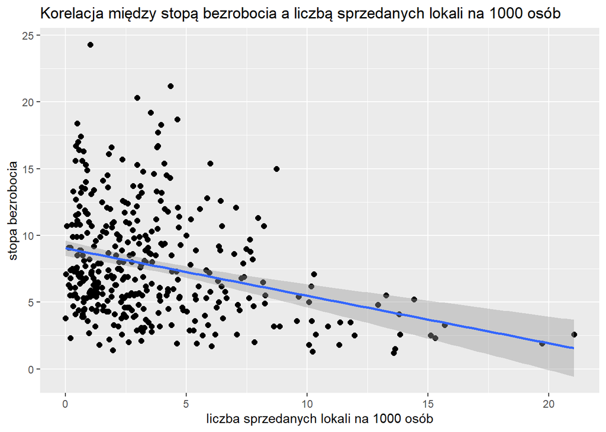

```r
ggplot(df,aes(x = Lokale_na_1000_mieszk, y= Stopa_bezrobocia)) +
  geom_point(size = 2) + geom_smooth(method = lm) +
labs(title = "Korelacja między stopą bezrobocia a liczbą sprzedanych lokali na 1000 osób", x= "liczba sprzedanych lokali na 1000 osób", y = "stopa bezrobocia")
```

```r
cor.test(df$Lokale_na_1000_mieszk, df$Stopa_bezrobocia)
```

```
##
##  Pearson's product-moment correlation
##
## data:  df$Lokale_na_1000_mieszk and df$Stopa_bezrobocia
## t = -5.8662, df = 376, p-value = 9.782e-09
## alternative hypothesis: true correlation is not equal to 0
## 95 percent confidence interval:
##  -0.3793532 -0.1943747
## sample estimates:
##        cor
## -0.2895653
```

Podobną analizę dokonaliśmy, próbując odpowiedzieć na pytanie, czy istnieje korelacja pomiędzy ilością sprzedanych lokali na 1000 mieszkańców, a stopą bezrobocia w danym powiecie. Tym razem wartość współczynnika Pearsona wyniosła -0,29 co świadczy o umiarkowanej korelacji. Korelacja jest jednak ujemna, tzn., im mniejsza stopa bezrobocia tym większa sprzedaż. Jest to całkiem logiczny wniosek. P-value potwierdza nas w przekonaniu o istotności wyniku.